# 6.0_models_r2r

Indra Boving

2025-02-14

#Setup

Need: MPa, LAI, LMA, LWA data

# DATA:

```r
data_og_cwc <- read_csv(here("processed-data", paste0("cwc_analysis",datver,".csv")), show_col_types = F) %>%
  filter(species %in% c("blue oak")) %>%
  select(tree, week, water_potential, cwc, time_season, time, site, date_wp, date_shift) %>%
  mutate(water_potential = -1*water_potential) %>%
  distinct() %>%
   # filter(!tree %in% c(2012, 2011)) %>%
  filter(!(tree %in% c(2346))) %>% #this tree seems to have a problem with post-leafout cwc - all 0s - likely becuase the canopy was too small to see.
  filter(!week %in% c(11, 9, 18)) #week 11 only has 9 midday measurements and acts really odd (2022-03-15), 9 just had 3 measurements

##LMA, LWA, LWC data:
data_qudo_lma <- read_csv(here("processed-data", paste0("wp_wc_rwc_",datver,".csv"))) %>%
 # filter(time %in% c("md")) %>%
  group_by(tree, week) %>%
  mutate(lma_g_cm2 = mean(lma_g_cm2, na.rm = T),
         water_potential = -1*water_potential) %>%
  filter(species %in% c("blue oak")) %>%
  select(week, time, tree, species, lma_g_cm2, water_potential, lwc_mean, lwa_g_cm2) %>%
  distinct()

df0 <- merge(data_qudo_lma, data_og_cwc %>% select(-water_potential),
            , by = c("tree", "week", "time"), all = T) %>%
  mutate(season = case_when(
    week %in% c(1:29) ~ "spring/early summer",
    week %in% c(30:45) ~ "late summer/fall"
  ))

##LAI data:

data_qudo_lai_spring <-  read_csv(here("final_data", "LAI_final.csv")) %>%
  clean_names() %>%
  select(treestr, springlai) %>%
  mutate(tree = as.numeric(treestr))

lai_raw <-  read_csv(here("final_data", "LAI_final.csv")) %>%
  clean_names() %>%
  select(-difflai, -species, -springstdev)

data_qudo_lai_df <-  lai_raw %>%
  pivot_longer(names_to = "time",
               values_to = "lai",
               cols = c(2:5)) %>%
  mutate(tree = as.numeric(treestr)) %>%
  mutate(season = case_when(
    time %in% c("springlai") ~ "spring/early summer",
    time %in% c("septlai") ~ "late summer/fall"
  )) %>%
  drop_na(season) %>%
  select(-time)

df <- merge(df0, data_qudo_lai_df,
            by = c("tree", "season"),
            all.x = T)

df_nodates <- df %>%
  filter(is.na(date_wp))
```

Data explanation:

- LMa and LWa are measured concurrent with WP (and CWC when those occured)
- LAI is from 2 measurements: spring and september. Spring LAI is associated with CWC and in-situ data from start of campaign (March) though July, September LAI is associated with sampling dates in August and September.

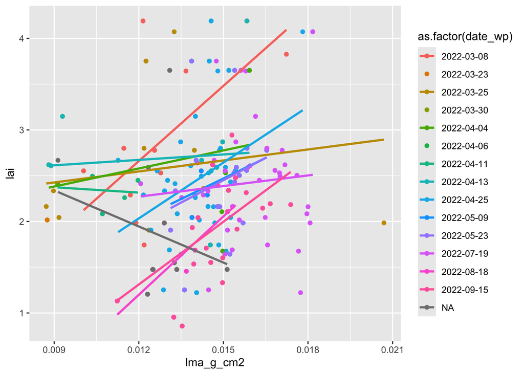

```r
df %>%
  ggplot(aes(y = lai,
             x = lma_g_cm2,
             #color = time_season,
             color = as.factor(date_wp))) +
  geom_point()+
  geom_smooth(method = "lm", se = F)
```

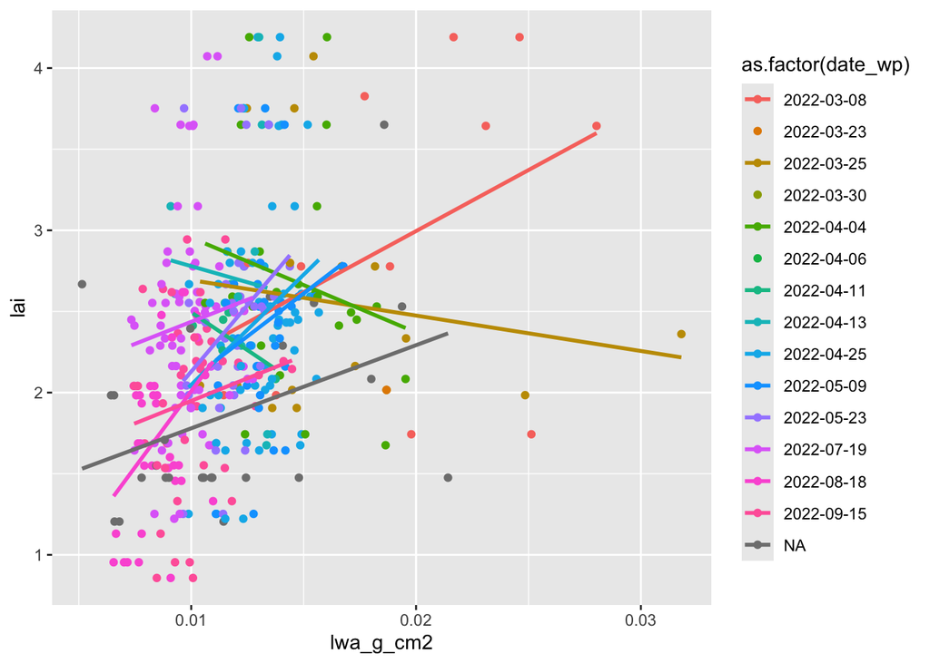

```r
df %>%
  ggplot(aes(y = lai,
             x = lwa_g_cm2,
             color = as.factor(date_wp))) +
  geom_point() +
  geom_smooth(method = "lm", se = F)
```

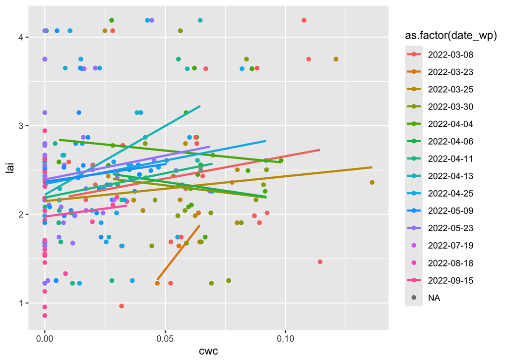

```r
df %>%
  ggplot(aes(y = lai,
             x = cwc,
             color = as.factor(date_wp))) +
  geom_point() +
  geom_smooth(method = "lm", se = F)
```

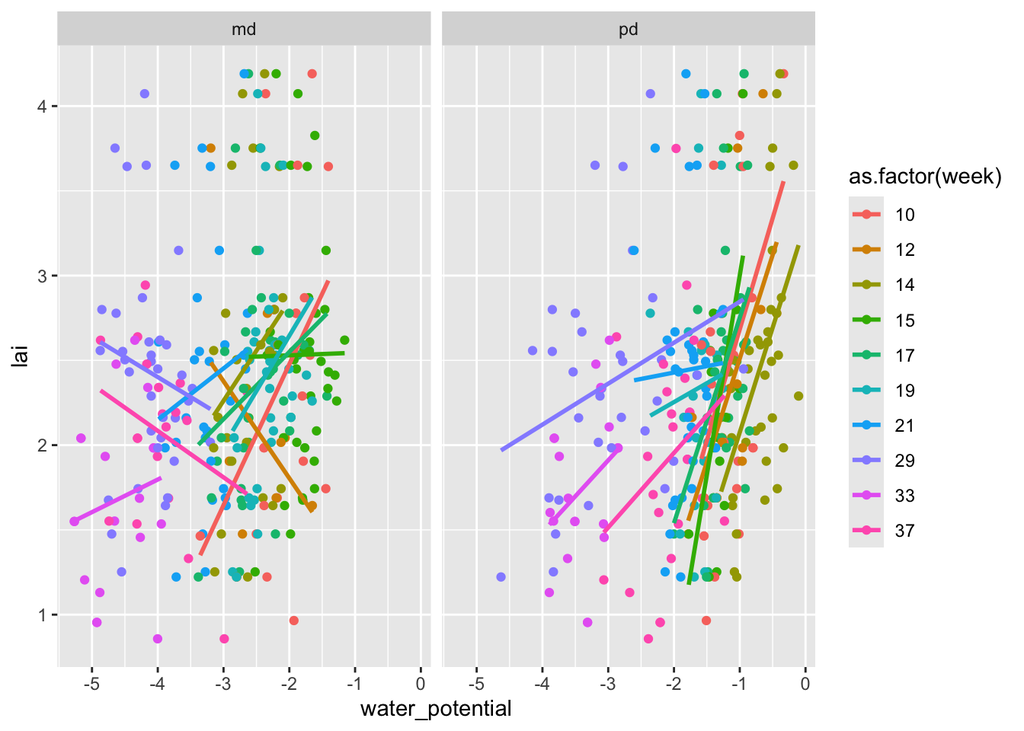

```r
df %>%
  ggplot(aes(y = lai,
             x = water_potential,
             color = as.factor(week))) +
  geom_point() +
  facet_wrap(~time) +
  geom_smooth(method = "lm", se = F)
```

# CWC models:

These do not account for spatial vs. temporal analysis with random effects, instead this is looking at relationships across the whole dataset:

```r
# Filter the data to exclude rows with missing values in the variables of interest
df_filtered <- df %>%
  filter(time %in% c("md"),
         cwc > 0) %>% #removing all of the 0 CWCs REALLY reduces the sample size (>200 down to <100), but seems like we should...
  filter(!is.na(cwc) & !is.na(lma_g_cm2) & !is.na(water_potential) & !is.na(lai))

# Fit models suggested by reviewer 3:
model_lwa_lai <- lmer(cwc ~ lwa_g_cm2 * lai + (1 | tree), data = df_filtered)
model_lwc_lma_lai <- lmer(cwc ~ lwc_mean * lma_g_cm2 * lai + (1 | tree), data = df_filtered)

# Additional models
model_lai <- lmer(cwc ~ lai + (1 | tree), data = df_filtered) #does LAI along predict CWC?
model_cwc <- lmer(cwc ~ water_potential + (1 | tree), data = df_filtered) #does midday MPa predict CWC?
model_lma <- lmer(cwc ~ lma_g_cm2 + (1 | tree), data = df_filtered) #Does LMA?
model_time_season <- lmer(cwc ~ time_season + (1 | tree), data = df_filtered) #Does just being before vs. after leafout?
model_lwa <- lmer(cwc ~ lwa_g_cm2 + (1 | tree), data = df_filtered) #Does LWA? This is the ground level analogue to CWC, so it probably should if CWC actually captures leaf water...
model_lwc <- lmer(cwc ~ lwc_mean + (1 | tree), data = df_filtered) #Does LWC?

# List of models
models <- list(
  lwa_lai = model_lwa_lai,
  lwc_lma_lai = model_lwc_lma_lai,
  lai = model_lai,
  cwc = model_cwc,
  lma = model_lma,
  time_season = model_time_season,
  lwa = model_lwa,
  lwc = model_lwc
)

# Create a summary table of AIC for each model
model_summary <- bind_rows(
  lapply(names(models), function(model_name) {
    model <- models[[model_name]]
    model_aic <- AIC(model)
    model_coeffs <- tidy(model) %>% select(term, estimate) %>% pivot_wider(names_from = term, values_from = estimate)

    # Collect model structure (excluding random effect part)
    model_formula <- deparse(formula(model))
    model_formula <- gsub("\\s*\\+\\s*\\(1\\s*\\|\\s*tree\\)", "", model_formula)  # Remove random effect part

    model_data <- data.frame(
      model = model_formula,
      AIC = model_aic,
      delta_AIC = model_aic - min(sapply(models, AIC))
    )

    bind_cols(model_data, model_coeffs)
  })
)

# Get models within 10 AIC points of the top model
min_aic <- min(model_summary$AIC)
top_models <- model_summary %>% filter(AIC <= min_aic + 10) %>%
  arrange(delta_AIC)

# Save final table
write_csv(top_models, here("processed-data", "model results", "qudo_top_models_cwc.csv"))

# Print the table
print(top_models)
```

```
##                              model       AIC delta_AIC (Intercept) lwa_g_cm2
## 1                  cwc ~ lma_g_cm2 -391.0093 0.0000000  0.12244419        NA
## 2                   cwc ~ lwc_mean -390.6290 0.3802915 -0.02071005        NA
## 3 cwc ~ lwc_mean * lma_g_cm2 * lai -390.3206 0.6886443  0.09327971        NA
##           lai lwa_g_cm2:lai sd__(Intercept) sd__Observation    lwc_mean
## 1          NA            NA     0.010856811      0.02225910          NA
## 2          NA            NA     0.010757351      0.02092309  0.05859865
## 3 -0.02371138            NA     0.009515842      0.02098094 -0.12721828
##   lma_g_cm2 lwc_mean:lma_g_cm2 lwc_mean:lai lma_g_cm2:lai
## 1 -6.436914                 NA           NA            NA
## 2        NA                 NA           NA            NA
## 3 -9.568368           13.16329   0.07164646      2.828636
##   lwc_mean:lma_g_cm2:lai water_potential time_seasonbefore leafout
## 1                     NA              NA                        NA
## 2                     NA              NA                        NA
## 3              -5.694809              NA                        NA
```

Models the reviewer wanted us to look at:

```r
# Save separate table for specific models
selected_models <- model_summary %>% filter(model %in% c("cwc ~ lwa_g_cm2 * lai", "cwc ~ lwc_mean * lma_g_cm2 * lai", "cwc ~ lai")) %>%
  arrange(delta_AIC)
write_csv(selected_models, here("processed-data", "model results", "qudo_selected_models_cwc.csv"))

# Print the selected models table
print(selected_models)
```

```
##                              model       AIC  delta_AIC (Intercept) lwa_g_cm2
## 1 cwc ~ lwc_mean * lma_g_cm2 * lai -390.3206  0.6886443 0.093279706        NA
## 2                        cwc ~ lai -367.7691 23.2401613 0.008290377        NA
## 3            cwc ~ lwa_g_cm2 * lai -342.7874 48.2218852 0.011932410 0.1922101
##            lai lwa_g_cm2:lai sd__(Intercept) sd__Observation   lwc_mean
## 1 -0.023711383            NA     0.009515842      0.02098094 -0.1272183
## 2  0.010597347            NA     0.003812909      0.02569378         NA
## 3 -0.002993917     0.8341026     0.008763559      0.02330688         NA
##   lma_g_cm2 lwc_mean:lma_g_cm2 lwc_mean:lai lma_g_cm2:lai
## 1 -9.568368           13.16329   0.07164646      2.828636
## 2        NA                 NA           NA            NA
## 3        NA                 NA           NA            NA
##   lwc_mean:lma_g_cm2:lai water_potential time_seasonbefore leafout
## 1              -5.694809              NA                        NA
## 2                     NA              NA                        NA
## 3                     NA              NA                        NA
```

```r
print(model_lwc_lma_lai)
```

```
## Linear mixed model fit by REML ['lmerMod']
## Formula: cwc ~ lwc_mean * lma_g_cm2 * lai + (1 | tree)
##    Data: df_filtered
## REML criterion at convergence: -410.3206
## Random effects:
##  Groups   Name        Std.Dev.
##  tree     (Intercept) 0.009516
##  Residual             0.020981
## Number of obs: 88, groups:  tree, 34
## Fixed Effects:
##            (Intercept)                lwc_mean               lma_g_cm2
##                0.09328                -0.12722                -9.56837
##                    lai      lwc_mean:lma_g_cm2            lwc_mean:lai
##               -0.02371                13.16329                 0.07165
##          lma_g_cm2:lai  lwc_mean:lma_g_cm2:lai
##                2.82864                -5.69481
```

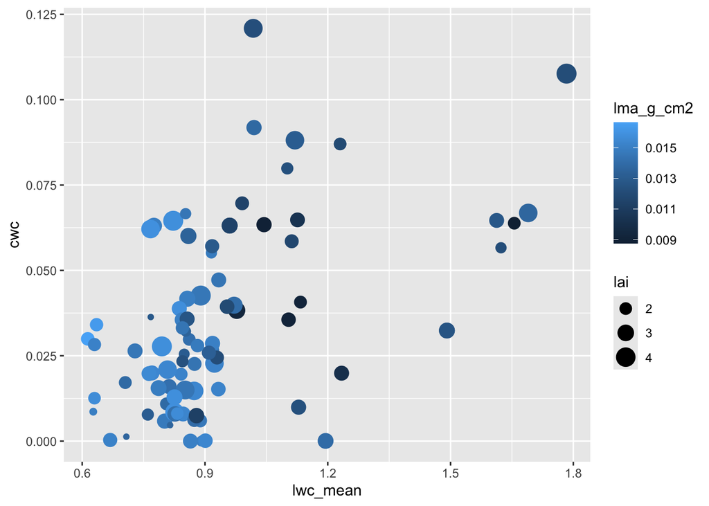

```r
#attempt to view:
ggplot(df_filtered, aes(y = cwc,
                x = lwc_mean,
                color = lma_g_cm2,
                size = lai)) +
  geom_point()
```

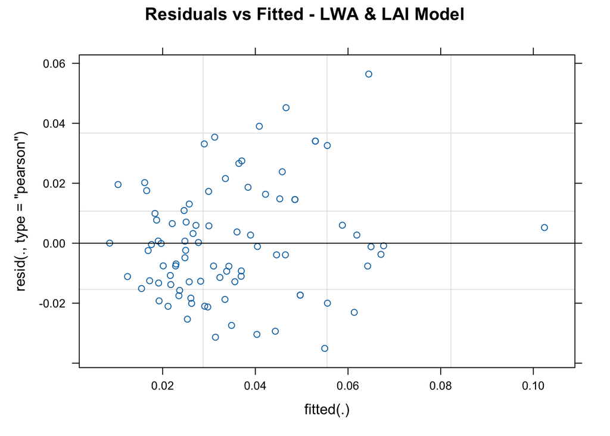

```r
# Model assumption checks for a single model
par(mfrow = c(2, 2))  # Set up a 2x2 plotting area

# Residuals vs. Fitted plot
plot(model_lwc_lma_lai, which = 1, main = "Residuals vs Fitted - LWA & LAI Model")
```

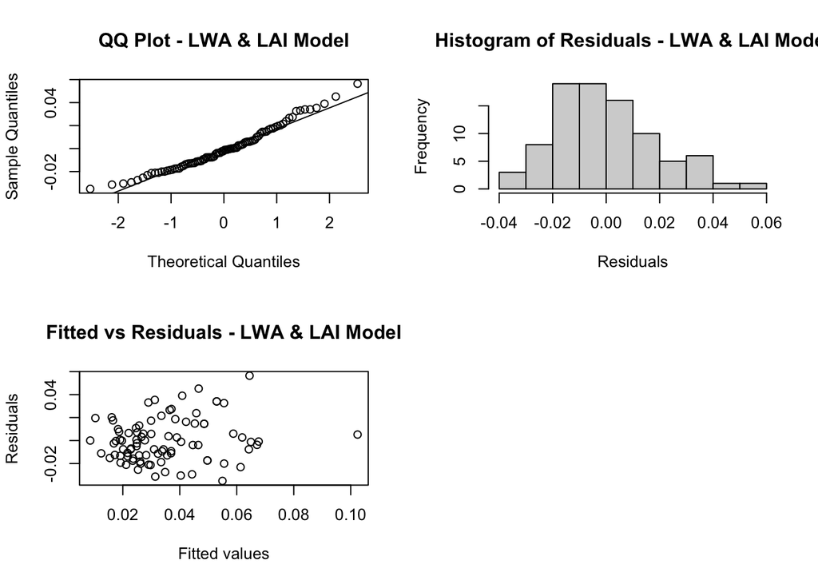

```r
# QQ Plot of residuals
qqnorm(residuals(model_lwc_lma_lai), main = "QQ Plot - LWA & LAI Model")
qqline(residuals(model_lwc_lma_lai))

# Histogram of residuals
hist(residuals(model_lwc_lma_lai), main = "Histogram of Residuals - LWA & LAI Model", xlab = "Residuals")

# Fitted values vs. Residuals
plot(fitted(model_lwc_lma_lai), residuals(model_lwc_lma_lai),
     main = "Fitted vs Residuals - LWA & LAI Model",
     xlab = "Fitted values", ylab = "Residuals")
```

# MPa models, just MIDDAYS:

```r
# Filter the data to exclude rows with missing values in the variables of interest
df_filtered <- df %>%
  filter(time %in% c("md"),
        # cwc > 0 #removing all of the 0 CWCs REALLY reduces the sample size, and also doesnt make a difference for the top mod.
         ) %>%
  filter(!is.na(cwc) & !is.na(lma_g_cm2) & !is.na(water_potential) & !is.na(lai))

# Fit models with different combinations of predictors
model_cwc <- lmer(water_potential ~ cwc + (1 | tree), data = df_filtered)
model_cwc_time <- lmer(water_potential ~ cwc*time_season + (1 | tree), data = df_filtered)
model_lma <- lmer(water_potential ~ lma_g_cm2 + (1 | tree), data = df_filtered)
model_lwa <- lmer(water_potential ~ lwa_g_cm2 + (1 | tree), data = df_filtered)
model_lwc <- lmer(water_potential ~ lwc_mean + (1 | tree), data = df_filtered)
model_lai <- lmer(water_potential ~ lai + (1 | tree), data = df_filtered)
model_lwa_lai <- lmer(water_potential ~ lai*lwa_g_cm2 + (1 | tree), data = df_filtered)
model_lwc_lma_lai <- lmer(water_potential ~ lai*lwc_mean*lma_g_cm2 + (1 | tree), data = df_filtered)


# List of models
models <- list(
  cwc = model_cwc,
  lma = model_lma,
  lwa = model_lwa,
  lwc = model_lwc,
  lai = model_lai,
  cwc_time = model_cwc_time,
  lwa_lai = model_lwa_lai,
  lwc_lma_lai = model_lwc_lma_lai
)


# Create a summary table of AIC for each model
model_summary <- bind_rows(
  lapply(names(models), function(model_name) {
    model <- models[[model_name]]
    model_aic <- AIC(model)
    model_coeffs <- tidy(model) %>% select(term, estimate) %>% pivot_wider(names_from = term, values_from = estimate)

    # Collect model structure (excluding random effect part)
    model_formula <- deparse(formula(model))
    model_formula <- gsub("\\s*\\+\\s*\\(1\\s*\\|\\s*tree\\)", "", model_formula)  # Remove random effect part

    model_data <- data.frame(
      model = model_formula,
      AIC = model_aic,
      delta_AIC = model_aic - min(sapply(models, AIC))
    )

    bind_cols(model_data, model_coeffs)
  })
)

# Get top 5 models by AIC
model_summary <- model_summary %>% arrange(AIC)
# Get models within 10 AIC points of the top model
min_aic <- min(model_summary$AIC)

top_models <- model_summary %>% filter(AIC <= min_aic + 50) %>%
  arrange(delta_AIC)


# Save final table
write_csv(top_models, here("processed-data", "model results", "qudo_top5_mems_mpa_middays.csv"))

# Print the table
print(top_models)
```

```
##                                          model      AIC delta_AIC (Intercept)
## 1 water_potential ~ lai * lwc_mean * lma_g_cm2 172.7654   0.00000    8.923651
## 2            water_potential ~ lai * lwa_g_cm2 215.3373  42.57193   -7.641566
##   cwc sd__(Intercept) sd__Observation lma_g_cm2 lwa_g_cm2  lwc_mean       lai
## 1  NA       0.2685252       0.4973921 -1183.856        NA -12.39531 -2.607908
## 2  NA       0.1295152       0.6269029        NA  401.3362        NA  1.023955
##   time_seasonbefore leafout cwc:time_seasonbefore leafout lai:lwa_g_cm2
## 1                        NA                            NA            NA
## 2                        NA                            NA     -77.48173
##   lai:lwc_mean lai:lma_g_cm2 lwc_mean:lma_g_cm2 lai:lwc_mean:lma_g_cm2
## 1     3.124353      270.9274           1276.932              -307.3872
## 2           NA            NA                 NA                     NA
```

Best model by AIC: *water_potential ~ lai * lwc_mean * lma_g_cm2*

```r
print(model_lwc_lma_lai)
```

```
## Linear mixed model fit by REML ['lmerMod']
## Formula: water_potential ~ lai * lwc_mean * lma_g_cm2 + (1 | tree)
##    Data: df_filtered
## REML criterion at convergence: 152.7654
## Random effects:
##  Groups   Name        Std.Dev.
##  tree     (Intercept) 0.2685
##  Residual             0.4974
## Number of obs: 120, groups:  tree, 35
## Fixed Effects:
##            (Intercept)                     lai                lwc_mean
##                  8.924                  -2.608                 -12.395
##              lma_g_cm2            lai:lwc_mean           lai:lma_g_cm2
##              -1183.856                   3.124                 270.927
##     lwc_mean:lma_g_cm2  lai:lwc_mean:lma_g_cm2
##               1276.932                -307.387
```

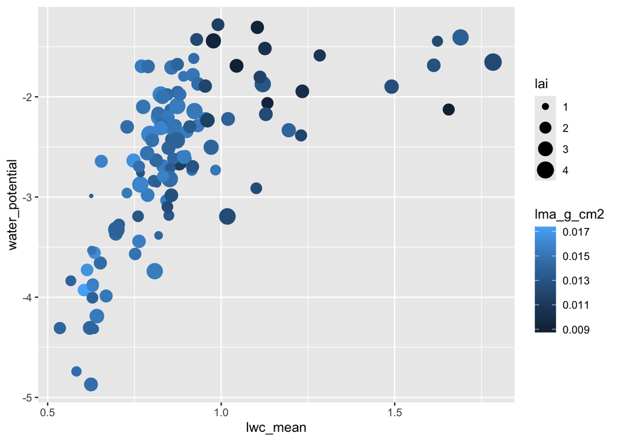

```r
#attempt to view:
ggplot(df_filtered, aes(y = water_potential,
                x = lwc_mean,
                color = lma_g_cm2,
                size = lai)) +
  geom_point()
```

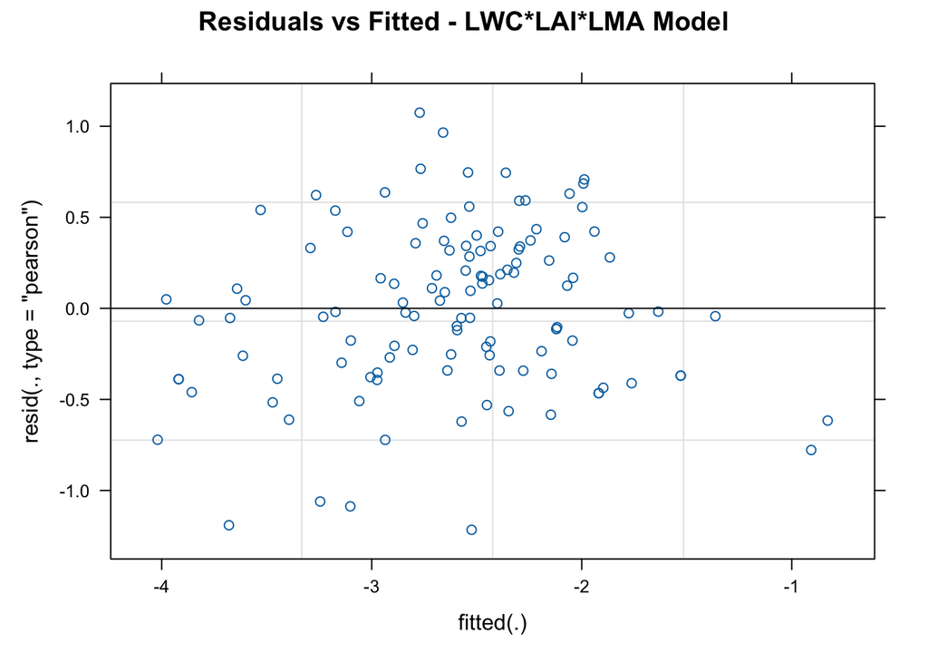

```r
# Model assumption checks for a single model
par(mfrow = c(2, 2))  # Set up a 2x2 plotting area

# Residuals vs. Fitted plot
plot(model_lwc_lma_lai, which = 1, main = "Residuals vs Fitted - LWC*LAI*LMA Model")
```

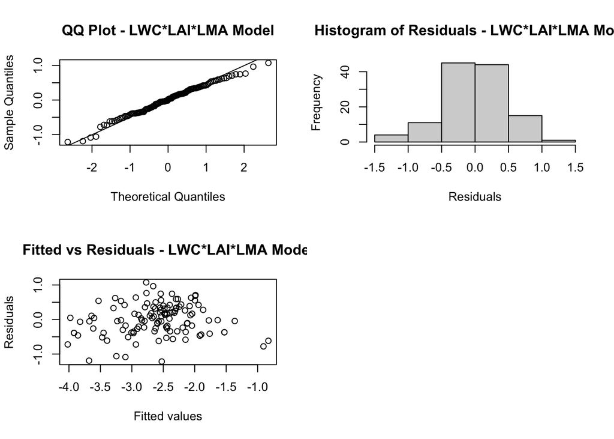

```r
# QQ Plot of residuals
qqnorm(residuals(model_lwc_lma_lai), main = "QQ Plot - LWC*LAI*LMA Model")
qqline(residuals(model_lwc_lma_lai))

# Histogram of residuals
hist(residuals(model_lwc_lma_lai), main = "Histogram of Residuals - LWC*LAI*LMA Model", xlab = "Residuals")

# Fitted values vs. Residuals
plot(fitted(model_lwc_lma_lai), residuals(model_lwc_lma_lai),
     main = "Fitted vs Residuals - LWC*LAI*LMA Model",
     xlab = "Fitted values", ylab = "Residuals")
```

# MPa models, just PREDAWN:

```r
# Filter the data to exclude rows with missing values in the variables of interest
df_filtered <- df %>%
  filter(time %in% c("pd"),
        # cwc > 0 #removing all of the 0 CWCs REALLY reduces the sample size, and also doesnt make a difference for the top mod.
         ) %>%
  filter(!is.na(cwc) & !is.na(lma_g_cm2) & !is.na(water_potential) & !is.na(lai))

# Fit models with different combinations of predictors
model_cwc <- lmer(water_potential ~ cwc + (1 | tree), data = df_filtered)
model_cwc_time <- lmer(water_potential ~ cwc*time_season + (1 | tree), data = df_filtered)
model_lma <- lmer(water_potential ~ lma_g_cm2 + (1 | tree), data = df_filtered)
model_lwa <- lmer(water_potential ~ lwa_g_cm2 + (1 | tree), data = df_filtered)
model_lwc <- lmer(water_potential ~ lwc_mean + (1 | tree), data = df_filtered)
model_lai <- lmer(water_potential ~ lai + (1 | tree), data = df_filtered)
model_lwa_lai <- lmer(water_potential ~ lai*lwa_g_cm2 + (1 | tree), data = df_filtered)
model_lwc_lma_lai <- lmer(water_potential ~ lai*lwc_mean*lma_g_cm2 + (1 | tree), data = df_filtered)


# List of models
models <- list(
  cwc = model_cwc,
  lma = model_lma,
  lwa = model_lwa,
  lwc = model_lwc,
  lai = model_lai,
  cwc_time = model_cwc_time,
  lwa_lai = model_lwa_lai,
  lwc_lma_lai = model_lwc_lma_lai
)


# Create a summary table of AIC for each model
model_summary <- bind_rows(
  lapply(names(models), function(model_name) {
    model <- models[[model_name]]
    model_aic <- AIC(model)
    model_coeffs <- tidy(model) %>% select(term, estimate) %>% pivot_wider(names_from = term, values_from = estimate)

    # Collect model structure (excluding random effect part)
    model_formula <- deparse(formula(model))
    model_formula <- gsub("\\s*\\+\\s*\\(1\\s*\\|\\s*tree\\)", "", model_formula)  # Remove random effect part

    model_data <- data.frame(
      model = model_formula,
      AIC = model_aic,
      delta_AIC = model_aic - min(sapply(models, AIC))
    )

    bind_cols(model_data, model_coeffs)
  })
)

# Get top 5 models by AIC
model_summary <- model_summary %>% arrange(AIC)
# Get models within 10 AIC points of the top model
min_aic <- min(model_summary$AIC)

top_models <- model_summary %>% filter(AIC <= min_aic + 50) %>%
  arrange(delta_AIC)


# Save final table
write_csv(top_models, here("processed-data", "model results", "qudo_top5_mems_mpa_middays.csv"))

# Print the table
print(top_models)
```

```
##                                          model      AIC delta_AIC (Intercept)
## 1          water_potential ~ cwc * time_season 104.0103   0.00000  -1.8220976
## 2 water_potential ~ lai * lwc_mean * lma_g_cm2 131.1311  27.12074   0.8859177
## 3                        water_potential ~ cwc 143.8867  39.87633  -1.7344556
## 4            water_potential ~ lai * lwa_g_cm2 153.0058  48.99545  -3.2601164
##        cwc sd__(Intercept) sd__Observation lma_g_cm2 lwa_g_cm2  lwc_mean
## 1 13.09723      0.07457983       0.3474842        NA        NA        NA
## 2       NA      0.07409005       0.4346321 -344.2705        NA -4.570152
## 3 12.33452      0.12102487       0.4042316        NA        NA        NA
## 4       NA      0.00000000       0.4556292        NA  102.2324        NA
##          lai time_seasonbefore leafout cwc:time_seasonbefore leafout
## 1         NA                  1.069498                     -13.54481
## 2 -0.4835963                        NA                            NA
## 3         NA                        NA                            NA
## 4  0.3778929                        NA                            NA
##   lai:lwa_g_cm2 lai:lwc_mean lai:lma_g_cm2 lwc_mean:lma_g_cm2
## 1            NA           NA            NA                 NA
## 2            NA     1.533405       84.0492            478.766
## 3            NA           NA            NA                 NA
## 4     -13.00475           NA            NA                 NA
##   lai:lwc_mean:lma_g_cm2
## 1                     NA
## 2              -144.4955
## 3                     NA
## 4                     NA
```

```r
print(model_cwc_time)
```

```
## Linear mixed model fit by REML ['lmerMod']
## Formula: water_potential ~ cwc * time_season + (1 | tree)
##    Data: df_filtered
## REML criterion at convergence: 92.0103
## Random effects:
##  Groups   Name        Std.Dev.
##  tree     (Intercept) 0.07458
##  Residual             0.34748
## Number of obs: 123, groups:  tree, 38
## Fixed Effects:
##                   (Intercept)                            cwc
##                        -1.822                         13.097
##     time_seasonbefore leafout  cwc:time_seasonbefore leafout
##                         1.069                        -13.545
```

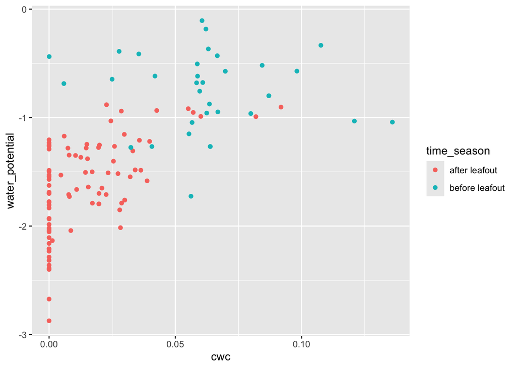

```r
#attempt to view:
ggplot(df_filtered, aes(y = water_potential,
                x = cwc,
                color = time_season)) +
  geom_point()
```

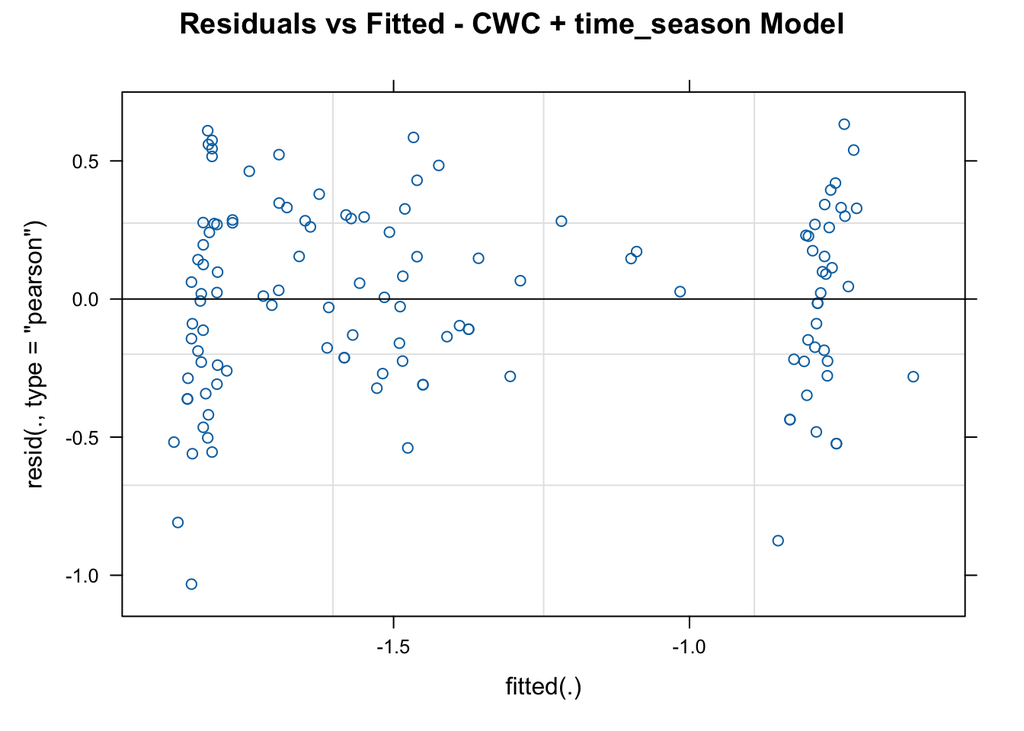

```r
# Model assumption checks for a single model
par(mfrow = c(2, 2))  # Set up a 2x2 plotting area

# Residuals vs. Fitted plot
plot(model_cwc_time, which = 1, main = "Residuals vs Fitted - CWC + time_season Model")
```

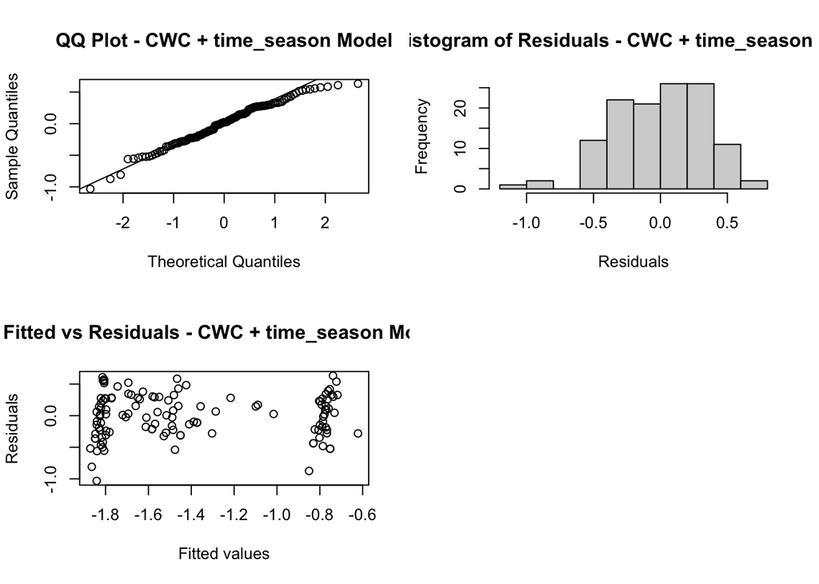

```r
# QQ Plot of residuals
qqnorm(residuals(model_cwc_time), main = "QQ Plot - CWC + time_season Model")
qqline(residuals(model_cwc_time))

# Histogram of residuals
hist(residuals(model_cwc_time), main = "Histogram of Residuals - CWC + time_season Model", xlab = "Residuals")

# Fitted values vs. Residuals
plot(fitted(model_cwc_time), residuals(model_cwc_time),
     main = "Fitted vs Residuals - CWC + time_season Model",
     xlab = "Fitted values", ylab = "Residuals")
```

But, there are so many CWC = 0 here, what happens if we remove them:

### MPa models, just PREDAWN, filtered CWC

```r
# Filter the data to exclude rows with missing values in the variables of interest
df_filtered <- df %>%
  filter(time %in% c("pd"),
         cwc > 0
         ) %>%
  filter(!is.na(cwc) & !is.na(lma_g_cm2) & !is.na(water_potential) & !is.na(lai))

# Fit models with different combinations of predictors
model_cwc <- lmer(water_potential ~ cwc + (1 | tree), data = df_filtered)
model_cwc_time <- lmer(water_potential ~ cwc*time_season + (1 | tree), data = df_filtered)
model_lma <- lmer(water_potential ~ lma_g_cm2 + (1 | tree), data = df_filtered)
model_lwa <- lmer(water_potential ~ lwa_g_cm2 + (1 | tree), data = df_filtered)
model_lwc <- lmer(water_potential ~ lwc_mean + (1 | tree), data = df_filtered)
model_lai <- lmer(water_potential ~ lai + (1 | tree), data = df_filtered)
model_lwa_lai <- lmer(water_potential ~ lai*lwa_g_cm2 + (1 | tree), data = df_filtered)
model_lwc_lma_lai <- lmer(water_potential ~ lai*lwc_mean*lma_g_cm2 + (1 | tree), data = df_filtered)


# List of models
models <- list(
  cwc = model_cwc,
  lma = model_lma,
  lwa = model_lwa,
  lwc = model_lwc,
  lai = model_lai,
  cwc_time = model_cwc_time,
  lwa_lai = model_lwa_lai,
  lwc_lma_lai = model_lwc_lma_lai
)


# Create a summary table of AIC for each model
model_summary <- bind_rows(
  lapply(names(models), function(model_name) {
    model <- models[[model_name]]
    model_aic <- AIC(model)
    model_coeffs <- tidy(model) %>% select(term, estimate) %>% pivot_wider(names_from = term, values_from = estimate)

    # Collect model structure (excluding random effect part)
    model_formula <- deparse(formula(model))
    model_formula <- gsub("\\s*\\+\\s*\\(1\\s*\\|\\s*tree\\)", "", model_formula)  # Remove random effect part

    model_data <- data.frame(
      model = model_formula,
      AIC = model_aic,
      delta_AIC = model_aic - min(sapply(models, AIC))
    )

    bind_cols(model_data, model_coeffs)
  })
)

# Get top 5 models by AIC
model_summary <- model_summary %>% arrange(AIC)
# Get models within 10 AIC points of the top model
min_aic <- min(model_summary$AIC)

top_models <- model_summary %>% filter(AIC <= min_aic + 50) %>%
  arrange(delta_AIC)


# Save final table
write_csv(top_models, here("processed-data", "model results", "qudo_top5_mems_mpa_middays.csv"))

# Print the table
print(top_models)
```

```
##                                          model       AIC delta_AIC (Intercept)
## 1          water_potential ~ cwc * time_season  57.26824   0.00000   -1.664233
## 2 water_potential ~ lai * lwc_mean * lma_g_cm2  75.10147  17.83323    3.012307
## 3                        water_potential ~ cwc  96.66767  39.39943   -1.536550
## 4            water_potential ~ lai * lwa_g_cm2 100.66812  43.39988   -2.760192
##        cwc sd__(Intercept) sd__Observation lma_g_cm2 lwa_g_cm2  lwc_mean
## 1 9.287321     0.152393080       0.2849165        NA        NA        NA
## 2       NA     0.099786735       0.3877958 -465.4863        NA -5.561549
## 3 9.114705     0.153790389       0.3722768        NA        NA        NA
## 4       NA     0.004394316       0.4273115        NA  70.17115        NA
##          lai time_seasonbefore leafout cwc:time_seasonbefore leafout
## 1         NA                 0.9724953                     -10.60703
## 2 -0.8768764                        NA                            NA
## 3         NA                        NA                            NA
## 4  0.3840863                        NA                            NA
##   lai:lwa_g_cm2 lai:lwc_mean lai:lma_g_cm2 lwc_mean:lma_g_cm2
## 1            NA           NA            NA                 NA
## 2            NA      1.76568        113.32           523.5815
## 3            NA           NA            NA                 NA
## 4     -11.24212           NA            NA                 NA
##   lai:lwc_mean:lma_g_cm2
## 1                     NA
## 2               -160.287
## 3                     NA
## 4                     NA
```

Same thing! CWC time is still the top model:

```r
print(model_cwc_time)
```

```
## Linear mixed model fit by REML ['lmerMod']
## Formula: water_potential ~ cwc * time_season + (1 | tree)
##    Data: df_filtered
## REML criterion at convergence: 45.2682
## Random effects:
##  Groups   Name        Std.Dev.
##  tree     (Intercept) 0.1524
##  Residual             0.2849
## Number of obs: 89, groups:  tree, 38
## Fixed Effects:
##                   (Intercept)                            cwc
##                       -1.6642                         9.2873
##     time_seasonbefore leafout  cwc:time_seasonbefore leafout
##                        0.9725                       -10.6070
```

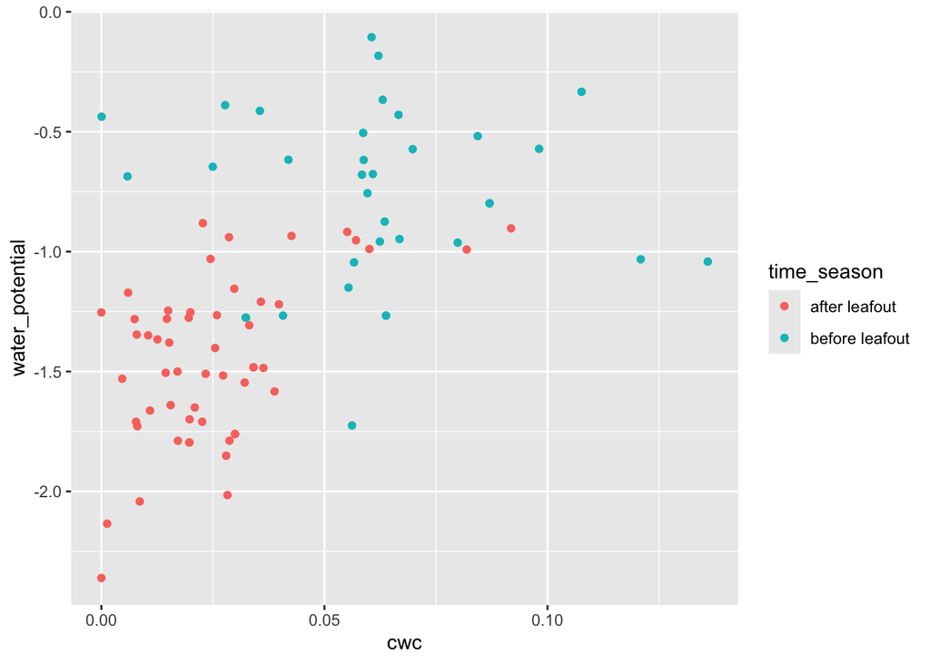

```r
#attempt to view:
ggplot(df_filtered, aes(y = water_potential,
                x = cwc,
                color = time_season)) +
  geom_point()
```

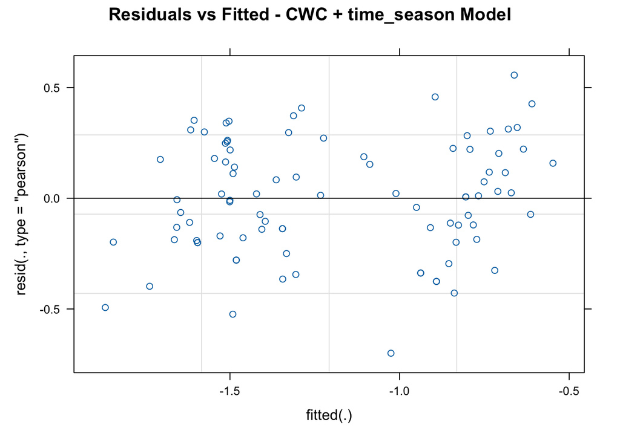

```r
# Model assumption checks for a single model
par(mfrow = c(2, 2))  # Set up a 2x2 plotting area

# Residuals vs. Fitted plot
plot(model_cwc_time, which = 1, main = "Residuals vs Fitted - CWC + time_season Model")
```

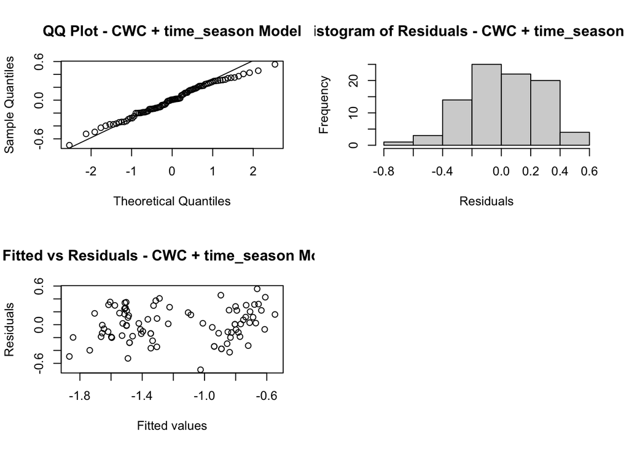

```r
# QQ Plot of residuals
qqnorm(residuals(model_cwc_time), main = "QQ Plot - CWC + time_season Model")
qqline(residuals(model_cwc_time))

# Histogram of residuals
hist(residuals(model_cwc_time), main = "Histogram of Residuals - CWC + time_season Model", xlab = "Residuals")

# Fitted values vs. Residuals
plot(fitted(model_cwc_time), residuals(model_cwc_time),
     main = "Fitted vs Residuals - CWC + time_season Model",
     xlab = "Fitted values", ylab = "Residuals")
```

# SPACE vs. TIME CWC.

Is this the correct way to use random effects? How to show this in paper, if we include it? New SI table or main text table?

What are the best predictors of CWC over space and time?

```r
#TIME:
model_lwa_lai_time <- lmer(cwc ~ lwa_g_cm2 * lai + (lwa_g_cm2 | tree) + (lai | tree), data = df_filtered) #random slope and intercept for LWA and LAI for each tree over time
model_lwc_lma_lai_time <- lmer(cwc ~ lwc_mean * lma_g_cm2 * lai + (lwa_g_cm2 | tree) + (lai | tree), data = df_filtered) #random slope and intercept for LWC, LMA, and LAI for each tree over time

#SPACE:
model_lwa_lai_space <- lmer(cwc ~ lwa_g_cm2 * lai + (lwa_g_cm2 | week) + (lai | week), data = df_filtered) #random slope and intercept for LWA and LAI for all trees in a given sample date
model_lwc_lma_lai_space <- lmer(cwc ~ lwc_mean * lma_g_cm2 * lai + (lwa_g_cm2 | week) + (lai | week), data = df_filtered) #random slope and intercept for LWC, LMA, and LAI for all trees in a given sample date

#DIEL not possible with CWC.
```